# Script Likert plots equity Fiji

2022-04-28

#####Load packages

```r
#load packages

#library(tidyverse) #there is an error with tidyverse
library(tidyr)
```

```r
library(ggplot2)
library(dplyr)
library(devtools)
library(stats)
library(ordinal)
library(MASS)
library(ggeffects)
library(effects)
library(scales)
#library(car) #for regression diagnostics
#library(broom) #for tidy output
#library(ggfortify) #for model diagnostics
#library(sjPlot) #for outputs
library(knitr) #for kable
#library(effects) #for partial effects plots
#library(MuMIn) #for interfacing with STAN
#library(emmeans) #for estimating marginal means
#library(ggeffects) #for partial effects plots
#library(MASS) #for glm.nb
#library(MuMIn) #for AICc
#library(DHARMa) #for residual diagnostics plots
#library(modelr) #for auxillary modelling functions
#library(performance) #for residuals diagnostics
#library(see) #for plotting residuals
library(patchwork) #for grids of plots
#library(brms)
#library(bayesplot)
library(coda)
#library(ggmcmc)
#library(broom) #for tidying outputs
library(tidybayes) #for more tidying outputs
#library(broom.mixed)#for summarising models
library(knitr)
library(likert)
```

#Arranging data set

Data 2016, treatment and control communities.

Change name of the data set #```{r}

data_fiji<-Fiji_data_notabu_2016_4

#```

```r
data_fiji<- read.csv ("Fiji_data_notabu_2016.4.csv",
                     header=TRUE,
                    dec=".")
```

Transform variables into factors (District, control/treatment)

```r
data_fiji$district<-as.factor(data_fiji$district) #district as factor
levels(data_fiji$district)
```

```
## [1] "Bureivanua/Nakorotubu" "Nakoilava/Nakorotubu"  "Nakorotubu/Nakorotubu"
## [4] "Navitilevu/Nakorotubu" "Navolau/Rakiraki"      "Rakiraki/Rakiraki"
## [7] "Raviravi/Rakiraki"
```

```r
data_fiji$village<-as.factor(data_fiji$village) #village as factor
levels(data_fiji$village)
```

```
##  [1] "Dama"       "Malake"     "Naivuvuni"  "Namuaimada" "Nasau"
##  [6] "Navolau 1"  "Navuniivi"  "Saioko"     "Soa"        "Veidrala"
```

```r
str(data_fiji$PES_exp)
```

```
##  chr [1:193] "Treatment" "Treatment" "Treatment" "Treatment" "Treatment" ...
```

```r
data_fiji$PES_exp<-as.factor(data_fiji$PES_exp) #control and treatment as factor
levels(data_fiji$PES_exp)# two leveles (control and treatment)
```

```
## [1] "Control"   "Treatment"
```

```r
dim(data_fiji) # n=193
```

```
## [1] 193 131
```

COVARIATES:

AGE

```r
#Age (nominal)

str(data_fiji$Age)
```

```
##  chr [1:193] "33" "35" "63" "69" "50" "40" "32" "34" "77" "73" "46" "60" ...
```

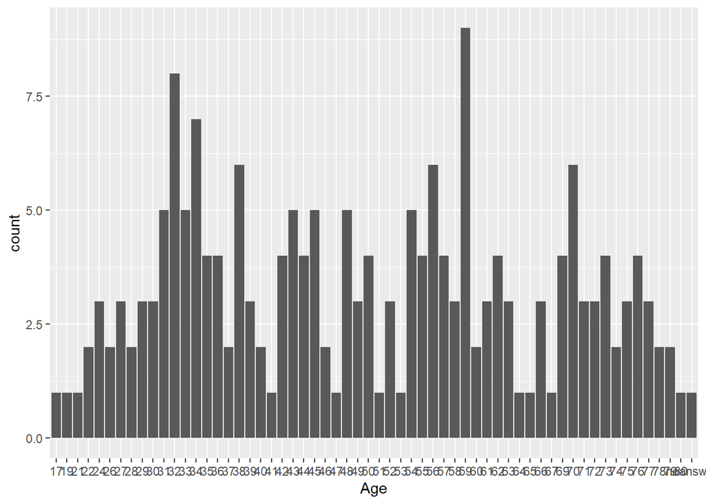

```r
ggplot(data_fiji,aes(Age))+geom_bar()
```

```r
data_fiji$Age_num<-as.numeric(as.character(data_fiji$Age))
```

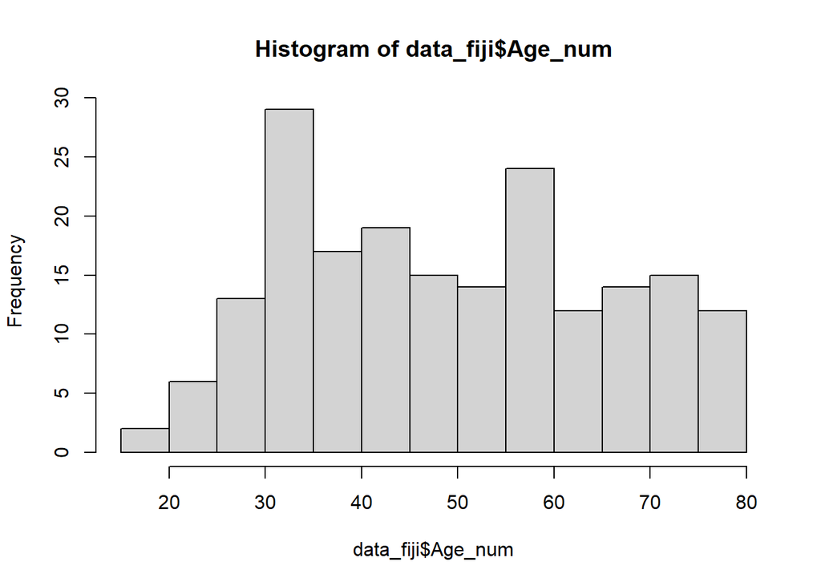

```r
hist(data_fiji$Age_num)
```

MIGRANT

```r
#Migrant status (Categorical)

str(data_fiji$Migrant)
```

```
##  int [1:193] 3 1 2 1 1 1 1 3 1 1 ...
```

```r
#transform in factor
data_fiji$Migrant<-as.factor(data_fiji$Migrant)
str(data_fiji$Migrant)
```

```
##  Factor w/ 4 levels "1","2","3","4": 3 1 2 1 1 1 1 3 1 1 ...
```

```r
#Combine Migrant levels 2,3 and 4

data_fiji$Migrant<-as.numeric(as.character( data_fiji$Migrant))
str(data_fiji$Migrant)
```

```
##  num [1:193] 3 1 2 1 1 1 1 3 1 1 ...
```

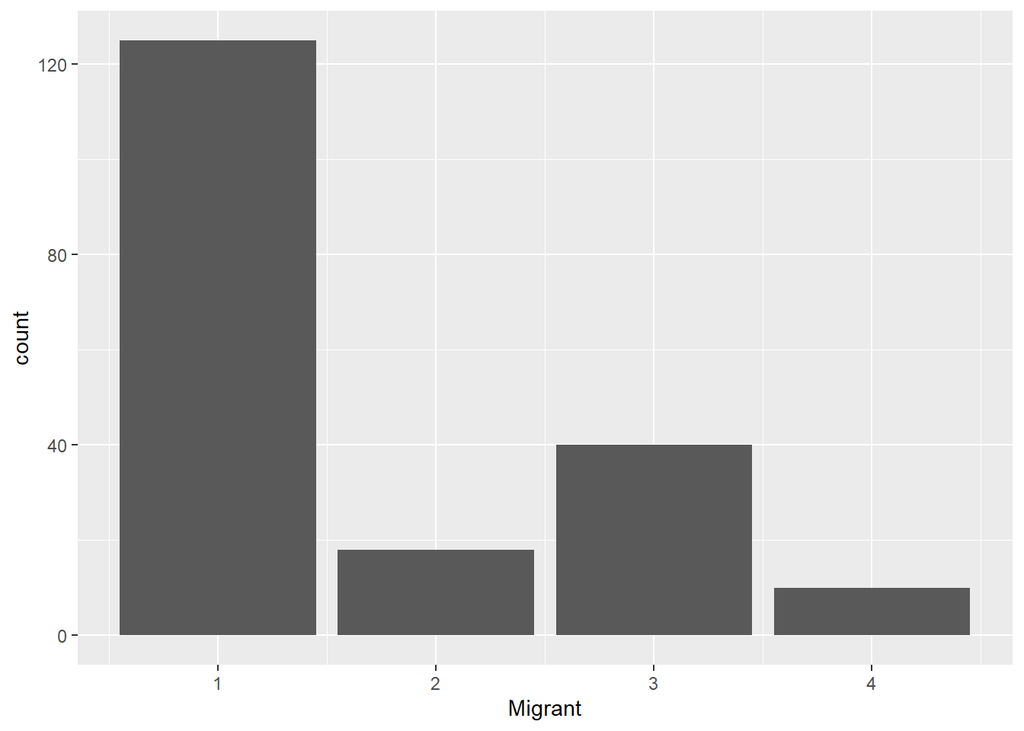

```r
data_fiji$migrant2 <- as.factor(ifelse(data_fiji$Migrant > 1,2,1))

ggplot(data_fiji,aes(Migrant))+geom_bar()
```

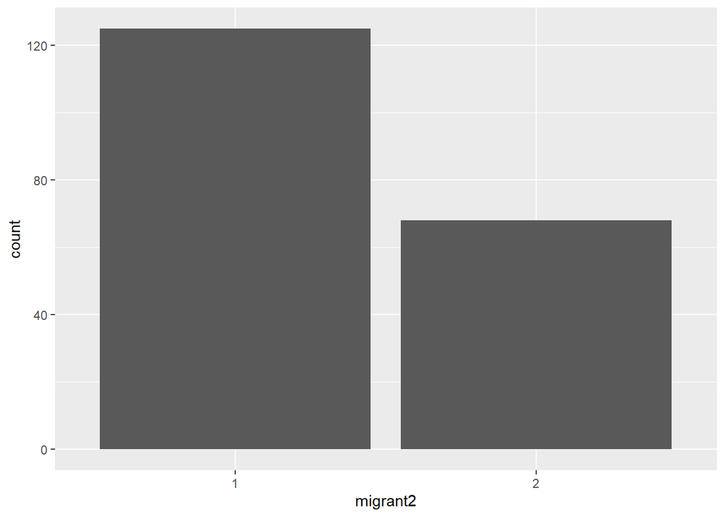

```r
ggplot(data_fiji,aes(migrant2))+geom_bar()
```

```r
#Years living in the village

str(data_fiji$Years_village)
```

```
##  int [1:193] 8 35 40 69 50 40 12 14 77 73 ...
```

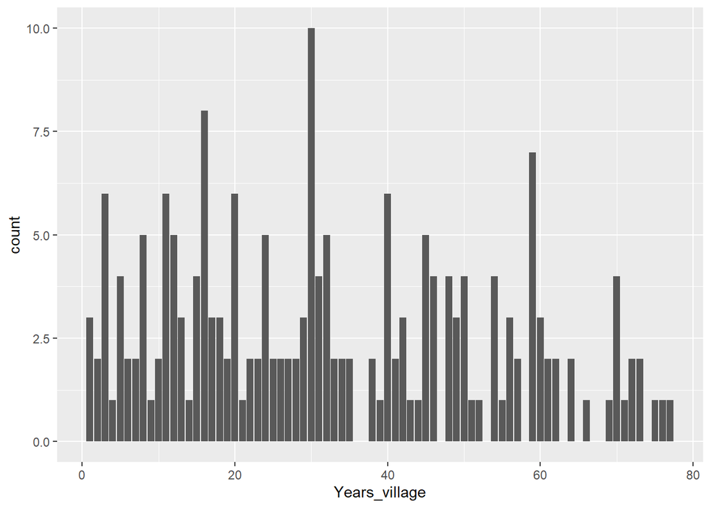

```r
ggplot(data_fiji,aes(Years_village))+geom_bar()
```

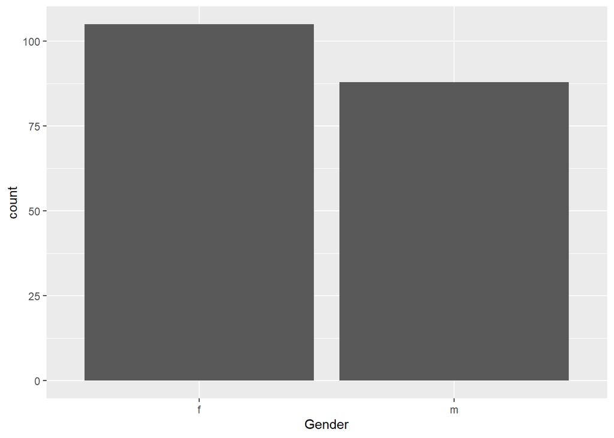

```r
#Gender

ggplot(data_fiji,aes(Gender))+geom_bar()
```

```r
str(data_fiji$Gender)
```

```
##  chr [1:193] "f" "m" "m" "m" "m" "m" "f" "f" "m" "m" "f" "f" "m" "m" "f" ...
```

```r
data_fiji$Gender<-as.factor(data_fiji$Gender)
```

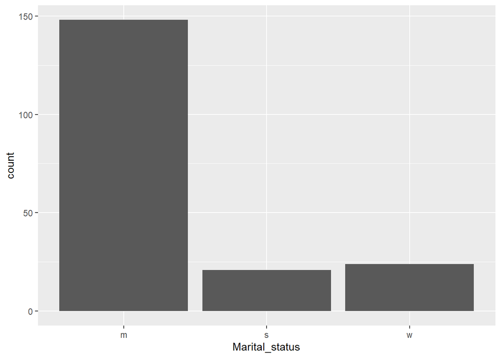

```r
#Marital status

ggplot(data_fiji,aes(Marital_status))+geom_bar()
```

```r
str(data_fiji$Marital_status)
```

```
##  chr [1:193] "m" "m" "m" "s" "m" "s" "s" "s" "m" "m" "m" "m" "m" "s" "w" ...
```

```r
data_fiji$Marital_status<-as.factor(data_fiji$Marital_status)
```

```r
#Education

str(data_fiji$Education)
```

```
##  chr [1:193] "Tertiary" "Secondary " "Secondary" "Primary" "Secondary" ...
```

```r
data_fiji$Education<-as.factor(data_fiji$Education)
str(data_fiji$Education)
```

```
##  Factor w/ 25 levels "0","Class 2",..: 25 21 18 16 18 18 18 18 16 16 ...
```

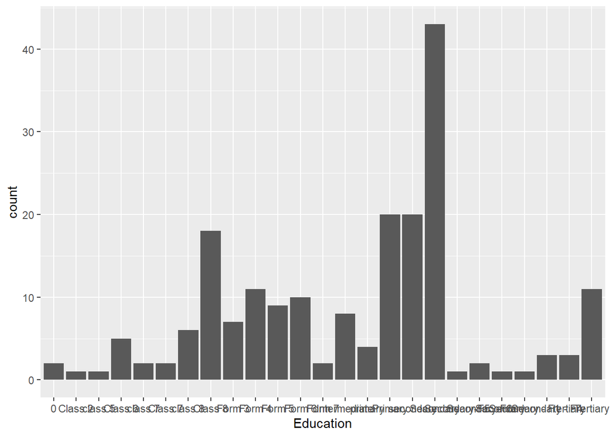

```r
ggplot(data_fiji,aes(Education))+geom_bar()
```

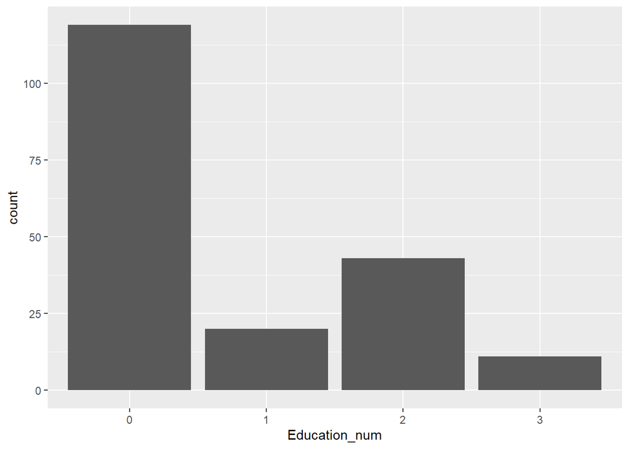

```r
data_fiji$Education_num<-as.factor(ifelse(data_fiji$Education == "Primary",1,
                                                   ifelse(data_fiji$Education=="Secondary",2,
                                                          ifelse(data_fiji$Education=="Tertiary",3,0))))


ggplot(data_fiji,aes(Education_num))+geom_bar()
```

```r
data_fiji$Education_num<-as.numeric(as.character(data_fiji$Education_num))

str(data_fiji$Education_num)
```

```
##  num [1:193] 3 0 2 1 2 2 2 2 1 1 ...
```

```r
#Transform in Primary, secondary and tertiary

data_fiji$Education<-recode_factor(data_fiji$Education, "Secondary-F5" = "Secondary")
levels(data_fiji$Education)
```

```
##  [1] "Secondary"      "0"              "Class 2"        "class 5"
##  [5] "Class 6"        "class 7"        "Class 7"        "class 8"
##  [9] "Class 8"        "Form 3"         "Form 4"         "Form 5"
## [13] "Form 6"         "Form 7"         "Intermediate"   "primary"
## [17] "Primary"        "secondary"      "Secondary-F6"   "Secondary "
## [21] "Secondary - F1" "Secondary - F4" "tertiary"       "Tertiary"
```

```r
data_fiji$Education<-recode_factor(data_fiji$Education, "Secondary-F6" = "Secondary")
levels(data_fiji$Education)
```

```
##  [1] "Secondary"      "0"              "Class 2"        "class 5"
##  [5] "Class 6"        "class 7"        "Class 7"        "class 8"
##  [9] "Class 8"        "Form 3"         "Form 4"         "Form 5"
## [13] "Form 6"         "Form 7"         "Intermediate"   "primary"
## [17] "Primary"        "secondary"      "Secondary "     "Secondary - F1"
## [21] "Secondary - F4" "tertiary"       "Tertiary"
```

```r
data_fiji$Education<-recode_factor(data_fiji$Education, "Secondary - F1" = "Secondary")
levels(data_fiji$Education)
```

```
##  [1] "Secondary"      "0"              "Class 2"        "class 5"
##  [5] "Class 6"        "class 7"        "Class 7"        "class 8"
##  [9] "Class 8"        "Form 3"         "Form 4"         "Form 5"
## [13] "Form 6"         "Form 7"         "Intermediate"   "primary"
## [17] "Primary"        "secondary"      "Secondary "     "Secondary - F4"
## [21] "tertiary"       "Tertiary"
```

```r
data_fiji$Education<-recode_factor(data_fiji$Education, "Secondary - F4" = "Secondary")
levels(data_fiji$Education)
```

```
##  [1] "Secondary"    "0"            "Class 2"      "class 5"      "Class 6"
##  [6] "class 7"      "Class 7"      "class 8"      "Class 8"      "Form 3"
## [11] "Form 4"       "Form 5"       "Form 6"       "Form 7"       "Intermediate"
## [16] "primary"      "Primary"      "secondary"    "Secondary "   "tertiary"
## [21] "Tertiary"
```

```r
data_fiji$Education<-recode_factor(data_fiji$Education, "primary" = "Primary")
levels(data_fiji$Education)
```

```
##  [1] "Primary"      "Secondary"    "0"            "Class 2"      "class 5"
##  [6] "Class 6"      "class 7"      "Class 7"      "class 8"      "Class 8"
## [11] "Form 3"       "Form 4"       "Form 5"       "Form 6"       "Form 7"
## [16] "Intermediate" "secondary"    "Secondary "   "tertiary"     "Tertiary"
```

```r
data_fiji$Education<-recode_factor(data_fiji$Education, "secondary"= "Secondary")
levels(data_fiji$Education)
```

```
##  [1] "Secondary"    "Primary"      "0"            "Class 2"      "class 5"
##  [6] "Class 6"      "class 7"      "Class 7"      "class 8"      "Class 8"
## [11] "Form 3"       "Form 4"       "Form 5"       "Form 6"       "Form 7"
## [16] "Intermediate" "Secondary "   "tertiary"     "Tertiary"
```

```r
data_fiji$Education<-recode_factor(data_fiji$Education, "tertiary"= "Tertiary")
levels(data_fiji$Education)
```

```
##  [1] "Tertiary"     "Secondary"    "Primary"      "0"            "Class 2"
##  [6] "class 5"      "Class 6"      "class 7"      "Class 7"      "class 8"
## [11] "Class 8"      "Form 3"       "Form 4"       "Form 5"       "Form 6"
## [16] "Form 7"       "Intermediate" "Secondary "
```

```r
data_fiji$Education<-recode_factor(data_fiji$Education, "Form 4"= "Tertiary")
levels(data_fiji$Education)
```

```
##  [1] "Tertiary"     "Secondary"    "Primary"      "0"            "Class 2"
##  [6] "class 5"      "Class 6"      "class 7"      "Class 7"      "class 8"
## [11] "Class 8"      "Form 3"       "Form 5"       "Form 6"       "Form 7"
## [16] "Intermediate" "Secondary "
```

```r
data_fiji$Education<-recode_factor(data_fiji$Education, "Form 3"= "Tertiary")
levels(data_fiji$Education)
```

```
##  [1] "Tertiary"     "Secondary"    "Primary"      "0"            "Class 2"
##  [6] "class 5"      "Class 6"      "class 7"      "Class 7"      "class 8"
## [11] "Class 8"      "Form 5"       "Form 6"       "Form 7"       "Intermediate"
## [16] "Secondary "
```

```r
data_fiji$Education<-recode_factor(data_fiji$Education, "Form 5"= "Tertiary")
levels(data_fiji$Education)
```

```
##  [1] "Tertiary"     "Secondary"    "Primary"      "0"            "Class 2"
##  [6] "class 5"      "Class 6"      "class 7"      "Class 7"      "class 8"
## [11] "Class 8"      "Form 6"       "Form 7"       "Intermediate" "Secondary "
```

```r
data_fiji$Education<-recode_factor(data_fiji$Education, "Form 6"= "Tertiary")
levels(data_fiji$Education)
```

```
##  [1] "Tertiary"     "Secondary"    "Primary"      "0"            "Class 2"
##  [6] "class 5"      "Class 6"      "class 7"      "Class 7"      "class 8"
## [11] "Class 8"      "Form 7"       "Intermediate" "Secondary "
```

```r
data_fiji$Education<-recode_factor(data_fiji$Education, "Form 7"= "Tertiary")
levels(data_fiji$Education)
```

```
##  [1] "Tertiary"     "Secondary"    "Primary"      "0"            "Class 2"
##  [6] "class 5"      "Class 6"      "class 7"      "Class 7"      "class 8"
## [11] "Class 8"      "Intermediate" "Secondary "
```

```r
data_fiji$Education<-recode_factor(data_fiji$Education, "Class 2"= "Secondary")
levels(data_fiji$Education)
```

```
##  [1] "Secondary"    "Tertiary"     "Primary"      "0"            "class 5"
##  [6] "Class 6"      "class 7"      "Class 7"      "class 8"      "Class 8"
## [11] "Intermediate" "Secondary "
```

```r
data_fiji$Education<-recode_factor(data_fiji$Education, "Class 5"= "Secondary")
levels(data_fiji$Education)
```

```
##  [1] "Secondary"    "Tertiary"     "Primary"      "0"            "class 5"
##  [6] "Class 6"      "class 7"      "Class 7"      "class 8"      "Class 8"
## [11] "Intermediate" "Secondary "
```

```r
data_fiji$Education<-recode_factor(data_fiji$Education, "Class 6"= "Secondary")
levels(data_fiji$Education)
```

```
##  [1] "Secondary"    "Tertiary"     "Primary"      "0"            "class 5"
##  [6] "class 7"      "Class 7"      "class 8"      "Class 8"      "Intermediate"
## [11] "Secondary "
```

```r
data_fiji$Education<-recode_factor(data_fiji$Education, "Class 7"= "Secondary")
levels(data_fiji$Education)
```

```
##  [1] "Secondary"    "Tertiary"     "Primary"      "0"            "class 5"
##  [6] "class 7"      "class 8"      "Class 8"      "Intermediate" "Secondary "
```

```r
data_fiji$Education<-recode_factor(data_fiji$Education, "class 7"= "Secondary")
levels(data_fiji$Education)
```

```
## [1] "Secondary"    "Tertiary"     "Primary"      "0"            "class 5"
## [6] "class 8"      "Class 8"      "Intermediate" "Secondary "
```

```r
data_fiji$Education<-recode_factor(data_fiji$Education, "class 5"= "Secondary")
levels(data_fiji$Education)
```

```
## [1] "Secondary"    "Tertiary"     "Primary"      "0"            "class 8"
## [6] "Class 8"      "Intermediate" "Secondary "
```

```r
data_fiji$Education<-recode_factor(data_fiji$Education, "class 8"= "Secondary")
levels(data_fiji$Education)
```

```
## [1] "Secondary"    "Tertiary"     "Primary"      "0"            "Class 8"
## [6] "Intermediate" "Secondary "
```

```r
data_fiji$Education<-recode_factor(data_fiji$Education, "Class 8"= "Secondary")
levels(data_fiji$Education)
```

```
## [1] "Secondary"    "Tertiary"     "Primary"      "0"            "Intermediate"
## [6] "Secondary "
```

```r
data_fiji$Education<-recode_factor(data_fiji$Education, "0"= "None")
levels(data_fiji$Education)
```

```
## [1] "None"         "Secondary"    "Tertiary"     "Primary"      "Intermediate"
## [6] "Secondary "
```

```r
data_fiji$Education<-recode_factor(data_fiji$Education, "Intermediate"= "Primary") #assuming intermediate is secondary. CHECKK!!!
levels(data_fiji$Education)
```

```
## [1] "Primary"    "None"       "Secondary"  "Tertiary"   "Secondary "
```

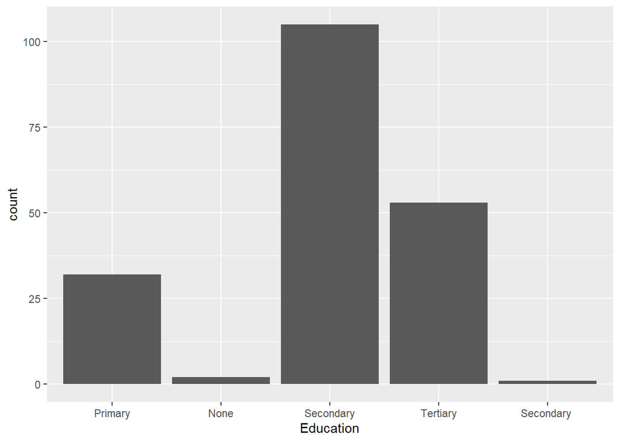

```r
ggplot(data_fiji,aes(Education))+geom_bar()
```

```r
data_fiji$Education_cat3<-as.factor(ifelse(data_fiji$Education == "Tertiary",3,
                                                   ifelse(data_fiji$Education=="Secondary",2,1)))
```

Wealth

I have calculated wealth using all assets and chose the one with loading factors higher than 0.4 (Gurney and Darling 2017. A Global Social-Ecological Systems Monitoring Framework for Coastal Fisheries Management: A Practical Monitoring Handbook)

calculate wealth (Material lifestyle)

```r
#dvd
str(data_fiji$dvd)
```

```
##  chr [1:193] "y" "y" "y" "n" "n" "y" "y" "n" "y" "y" "y" "n" "n" "n" "n" ...
```

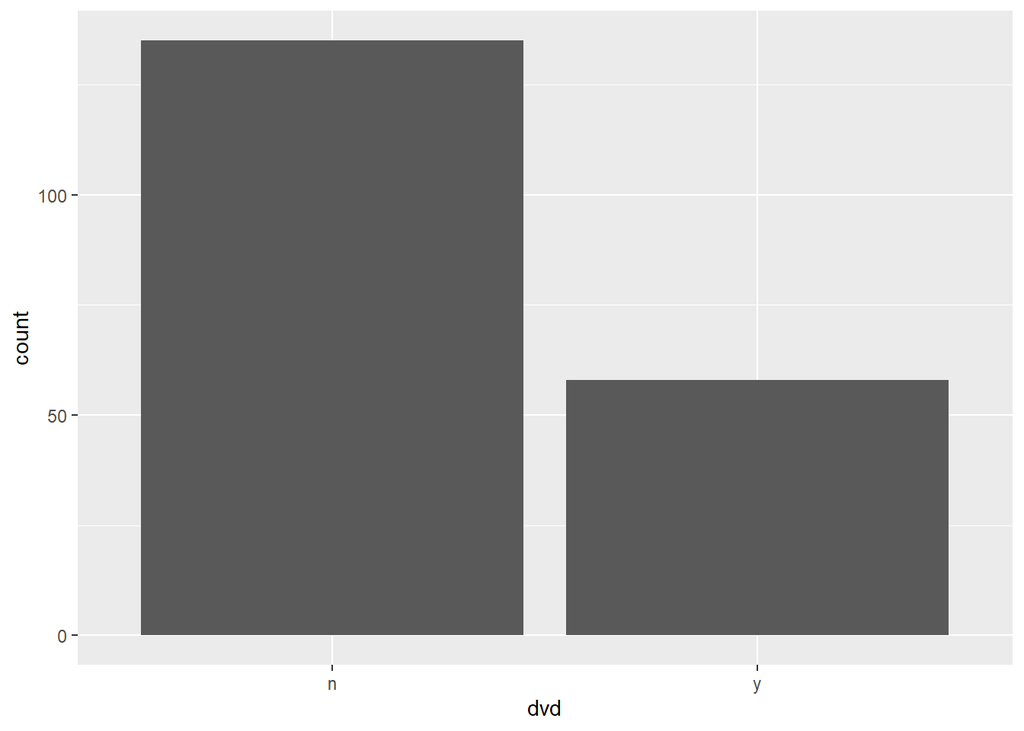

```r
data_fiji$dvd<-as.factor(data_fiji$dvd)
ggplot(data_fiji,aes(dvd))+geom_bar()
```

```r
which(is.na(data_fiji$dvd))
```

```
## integer(0)
```

```r
#washing
str(data_fiji$washing)
```

```
##  chr [1:193] "n" "n" "n" "n" "n" "n" "n" "n" "n" "n" "n" "n" "n" "n" "n" ...
```

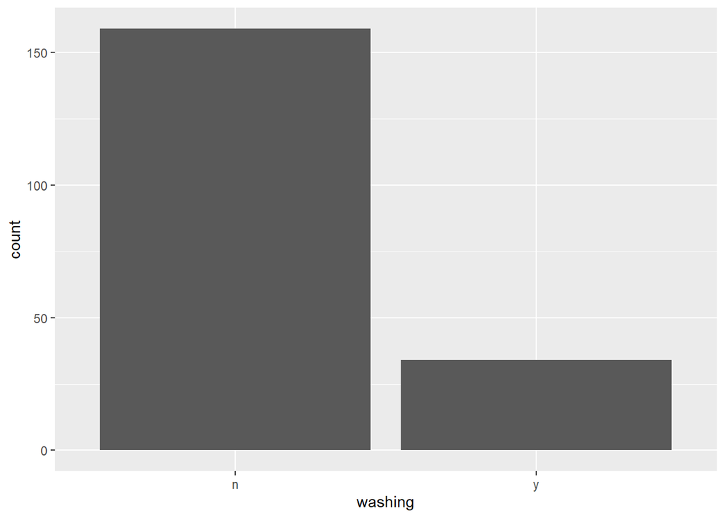

```r
data_fiji$washing<-as.factor(data_fiji$washing)
ggplot(data_fiji,aes(washing))+geom_bar()
```

```r
which(is.na(data_fiji$washing))
```

```
## integer(0)
```

```r
#computer
str(data_fiji$computer)
```

```
##  chr [1:193] "n" "n" "n" "n" "n" "n" "n" "n" "n" "n" "n" "n" "n" "n" "n" ...
```

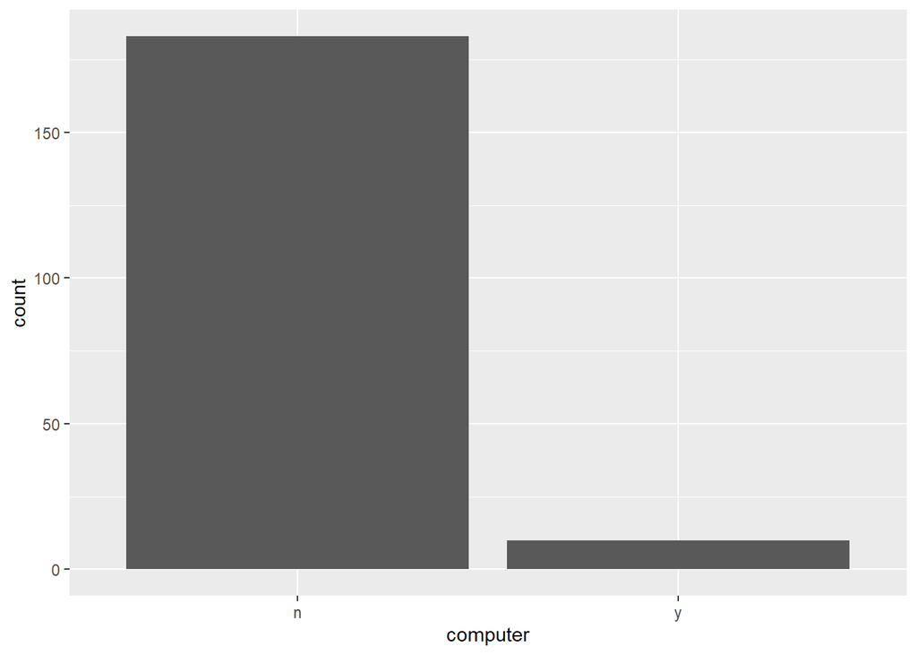

```r
data_fiji$computer<-as.factor(data_fiji$computer)
ggplot(data_fiji,aes(computer))+geom_bar()
```

```r
which(is.na(data_fiji$computer))
```

```
## integer(0)
```

```r
#fridge
str(data_fiji$fridge)
```

```
##  chr [1:193] "n" "n" "n" "n" "n" "n" "n" "n" "y" "n" "n" "n" "n" "n" "n" ...
```

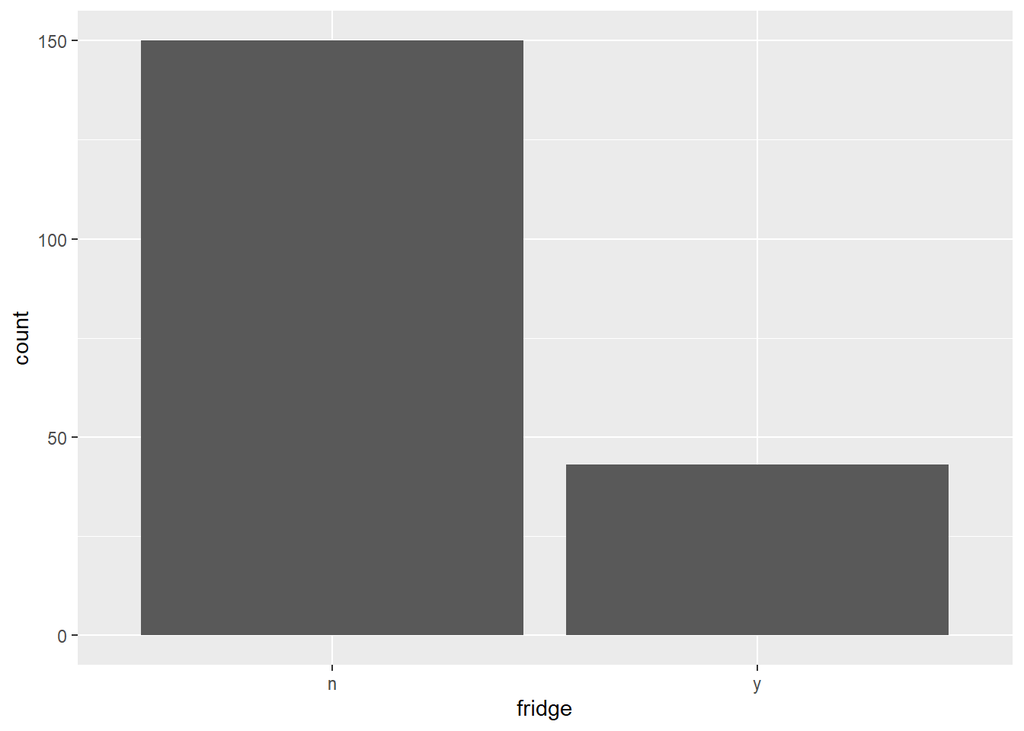

```r
data_fiji$fridge<-as.factor(data_fiji$fridge)
ggplot(data_fiji,aes(fridge))+geom_bar()
```

```r
which(is.na(data_fiji$fridge))
```

```
## integer(0)
```

```r
#tv
str(data_fiji$tv)
```

```
##  chr [1:193] "y" "y" "y" "n" "n" "y" "y" "y" "y" "n" "n" "n" "n" "n" "y" ...
```

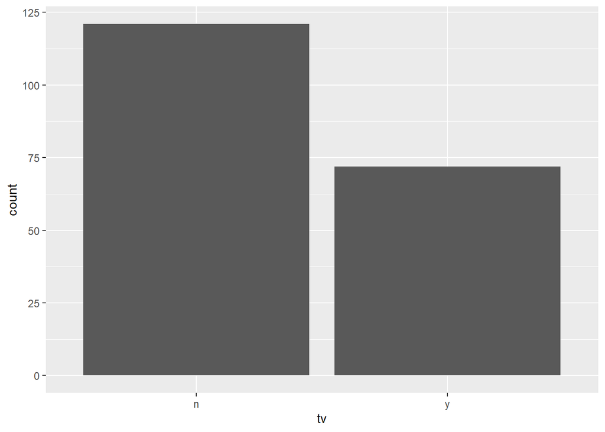

```r
data_fiji$tv<-as.factor(data_fiji$tv)
ggplot(data_fiji,aes(tv))+geom_bar()
```

```r
which(is.na(data_fiji$tv))
```

```
## integer(0)
```

```r
#satellite
str(data_fiji$satellite)
```

```
##  chr [1:193] "n" "n" "n" "n" "n" "n" "n" "n" "n" "n" "n" "n" "n" "n" "n" ...
```

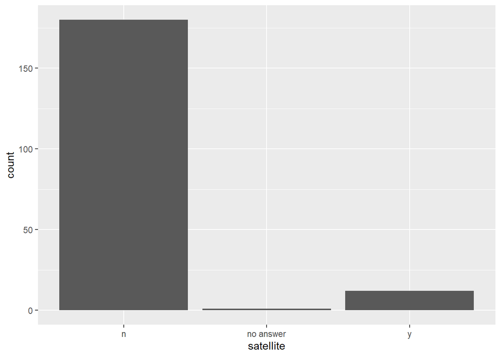

```r
data_fiji$satellite<-as.factor(data_fiji$satellite)
ggplot(data_fiji,aes(satellite))+geom_bar()
```

```r
data_fiji<-data_fiji%>%
  mutate(satellite=na_if(satellite, "no answer"))
which(is.na(data_fiji$satellite))#187 is missing
```

```
## [1] 187
```

```r
#recode rest of the variables

data_fiji$dvd<-recode_factor(data_fiji$dvd,"y" ="1")
data_fiji$dvd<-recode_factor(data_fiji$dvd,"n" ="0")

data_fiji$smartphone<-recode_factor(data_fiji$smartphone,"y" ="1")
data_fiji$smartphone<-recode_factor(data_fiji$smartphone,"n" ="0")

data_fiji$washing<-recode_factor(data_fiji$washing,"y" ="1")
data_fiji$washing<-recode_factor(data_fiji$washing,"n" ="0")

data_fiji$fridge<-recode_factor(data_fiji$fridge,"y" ="1")
data_fiji$fridge<-recode_factor(data_fiji$fridge,"n" ="0")

data_fiji$tv<-recode_factor(data_fiji$tv,"y" ="1")
data_fiji$tv<-recode_factor(data_fiji$tv,"n" ="0")

data_fiji$satellite<-recode_factor(data_fiji$satellite,"y" ="1")
data_fiji$satellite<-recode_factor(data_fiji$satellite,"n" ="0")

#transform variable into numeric vars
data_fiji$dvd<-as.numeric(as.character(data_fiji$dvd))
which(is.na(data_fiji$dvd))
```

```
## integer(0)
```

```r
data_fiji$washing<-as.numeric(as.character(data_fiji$washing))
which(is.na(data_fiji$washing))
```

```
## integer(0)
```

```r
data_fiji$fridge<-as.numeric(as.character(data_fiji$fridge))
which(is.na(data_fiji$fridge))
```

```
## integer(0)
```

```r
data_fiji$tv<-as.numeric(as.character(data_fiji$tv))
which(is.na(data_fiji$tv))
```

```
## integer(0)
```

```r
data_fiji$satellite<-as.numeric(as.character(data_fiji$satellite))
which(is.na(data_fiji$satellite)) #missing 187
```

```
## [1] 187
```

```r
#PCA 18 only have one missing value.

data_fiji<-data_fiji[-c(187),]
wealth_rows_pca18.2= data_fiji[, c("dvd", "washing","fridge","tv", "satellite")]
xord18.2<-prcomp(wealth_rows_pca18.2, center= TRUE, scale=TRUE)

summary(xord18.2)
```

```
## Importance of components:
##                           PC1    PC2    PC3     PC4     PC5
## Standard deviation     1.6008 1.0004 0.7855 0.67895 0.59890
## Proportion of Variance 0.5125 0.2002 0.1234 0.09219 0.07174
## Cumulative Proportion  0.5125 0.7127 0.8361 0.92826 1.00000
```

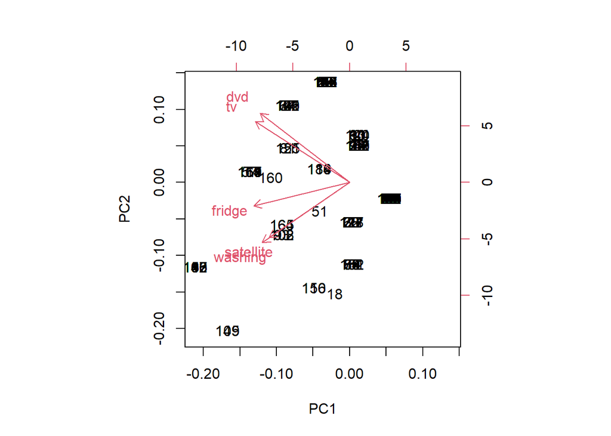

```r
biplot(xord18.2)
```

```r
loadings18.2<-xord18.2$rotation #rotation is the matrix of variable loadings (columns are eigenvectors) in prcomp() function
loadings18.2
```

```
##                  PC1        PC2         PC3         PC4         PC5
## dvd       -0.4456042  0.5510784 -0.10704930  0.23661393 -0.65597547
## washing   -0.4359240 -0.4797544  0.32211120  0.68440724  0.08739014
## fridge    -0.4779007 -0.1855376  0.52473662 -0.66155942 -0.15549067
## tv        -0.4702871  0.4877233 -0.06487272 -0.02063843  0.73233979
## satellite -0.4023035 -0.4402841 -0.77796391 -0.19368470 -0.03949986
```

```r
#extract pc1


myscores.2<-xord18.2$x # "x" are the coordinates of the individuals (observations) on the principal components in prcomp()

data_fiji$wealth_msl.2<-myscores.2[,"PC1"] #add this to fiji_data and add na to the empty cells

data_fiji$wealth_msl.2
```

```
##   [1] -0.7388053 -0.7388053 -0.7388053  1.2056164  1.2056164 -0.7388053
##   [7] -0.7388053  0.2339693 -1.8918196  0.2328417  0.2328417  1.2056164
##  [13]  1.2056164  1.2056164  0.2339693  1.2056164 -0.7388053 -0.4520388
##  [19]  1.2056164  1.2056164  1.2056164 -0.7388053  1.2056164  0.2339693
##  [25]  1.2056164 -0.7388053  1.2056164  0.0526021  1.2056164  0.2328417
##  [31]  1.2056164  0.2339693  1.2056164  1.2056164  1.2056164  1.2056164
##  [37] -1.8918196  1.2056164 -0.7388053  1.2056164  1.2056164  1.2056164
##  [43]  1.2056164  1.2056164  1.2056164  1.2056164 -0.7388053  1.2056164
##  [49]  1.2056164  1.2056164 -0.9049950 -0.7388053 -0.7388053  1.2056164
##  [55]  1.2056164  1.2056164 -3.0307839  1.2056164  1.2056164  0.0526021
##  [61]  1.2056164  1.2056164  0.2328417  1.2056164  1.2056164  1.2056164
##  [67] -1.8918196  0.0666521  1.2056164  0.2339693  1.2056164  0.0526021
##  [73]  1.2056164 -1.8918196  0.0666521  1.2056164  1.2056164  1.2056164
##  [79]  0.0666521  0.0666521 -1.8777696 -0.7388053  1.2056164  0.0666521
##  [85]  1.2056164  1.2056164  1.2056164  1.2056164  1.2056164  0.2328417
```

[output cut: 17 more lines]

```r
str(data_fiji$wealth_msl.2)
```

```
##  num [1:192] -0.739 -0.739 -0.739 1.206 1.206 ...
```

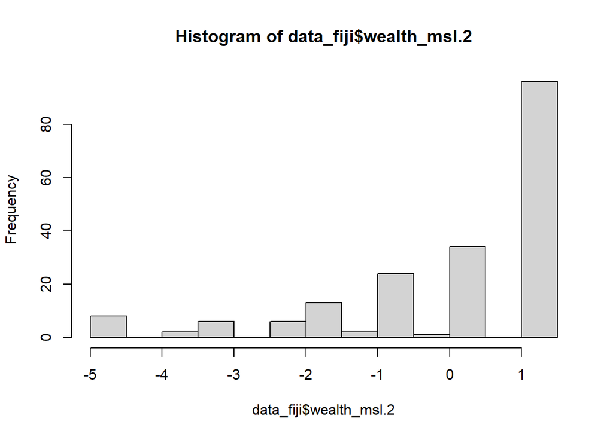

```r
data_fiji$wealth_msl.2_sc.1<-scale( data_fiji$wealth_msl.2, center = TRUE,scale=TRUE)


data_fiji$wealth_msl.2.resc<- rescale(data_fiji$wealth_msl.2, to = c(0,1)) #rescale

hist(data_fiji$wealth_msl.2)
```

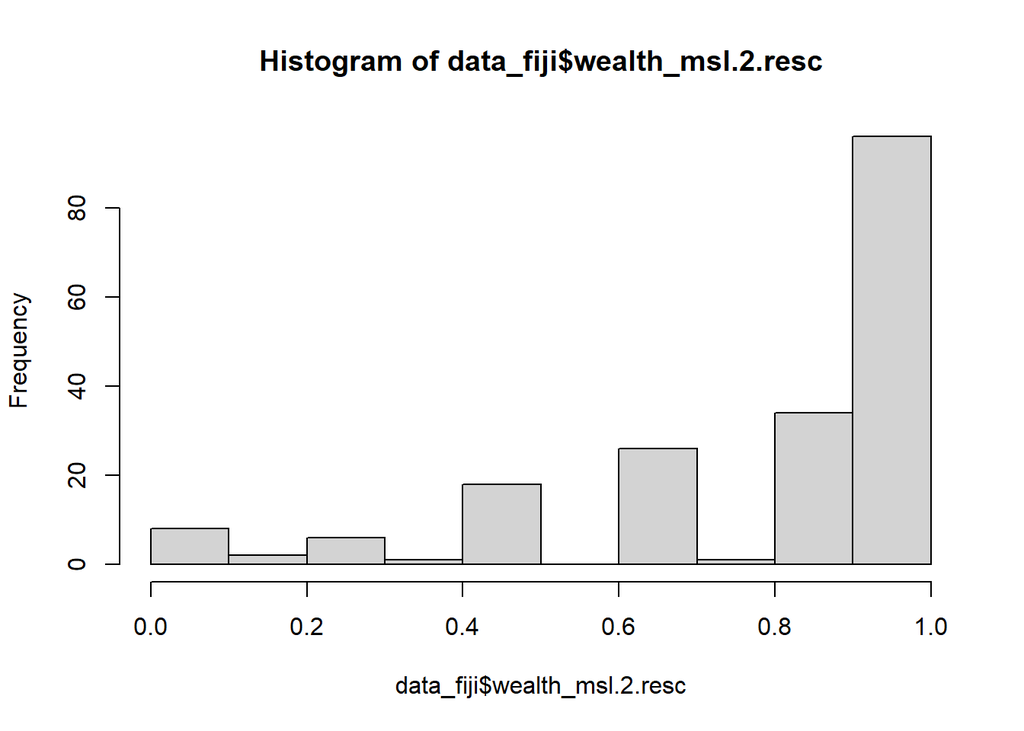

```r
hist(data_fiji$wealth_msl.2.resc)
```

```r
data_fiji$wealth2<-data_fiji$wealth_msl.2.resc
```

```r
#gender (Gender)
str(data_fiji$Gender)
```

```
##  Factor w/ 2 levels "f","m": 1 2 2 2 2 2 1 1 2 2 ...
```

```r
#marital status
str(data_fiji$Marital_status)
```

```
##  Factor w/ 3 levels "m","s","w": 1 1 1 2 1 2 2 2 1 1 ...
```

```r
#age (Age)
str(data_fiji$Age_num)
```

```
##  num [1:192] 33 35 63 69 50 40 32 34 77 73 ...
```

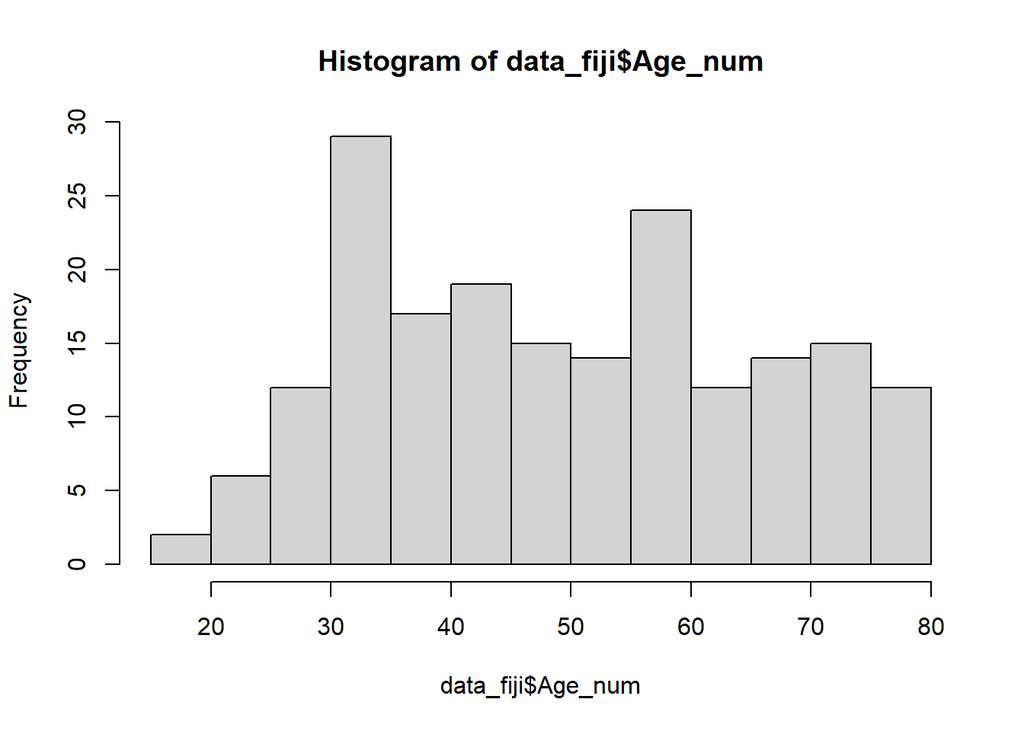

```r
hist(data_fiji$Age_num)
```

```r
#migrant status (migrant2)
str(data_fiji$migrant2)
```

```
##  Factor w/ 2 levels "1","2": 2 1 2 1 1 1 1 2 1 1 ...
```

```r
#years in the village
str(data_fiji$Years_village)
```

```
##  int [1:192] 8 35 40 69 50 40 12 14 77 73 ...
```

```r
#education (Education)
str(data_fiji$Education)
```

```
##  Factor w/ 5 levels "Primary","None",..: 4 5 3 1 3 3 3 3 1 1 ...
```

```r
str(data_fiji$Education_cat3)
```

```
##  Factor w/ 3 levels "1","2","3": 3 1 2 1 2 2 2 2 1 1 ...
```

```r
#wealth
str(data_fiji$wealth_msl.2)
```

```
##  num [1:192] -0.739 -0.739 -0.739 1.206 1.206 ...
```

```r
str(data_fiji$wealth2)
```

```
##  num [1:192] 0.67 0.67 0.67 1 1 ...
```

Standardize

```r
# Scale all "numerical" variables from 0 to 1
#migrant: binomial

#data_fiji$n_children_sd <- scale(data_fiji$n_children)*0.5
data_fiji$wealth2_sd <- scale(data_fiji$wealth2)*0.5
data_fiji$Years_village_sd<-scale(data_fiji$Years_village)*0.5
data_fiji$Age_num_sd <- scale(data_fiji$Age_num)*0.5
```

Save data with previous steps

```r
#write.csv(data_fiji,'data_fiji2.2.csv')
```

RESPONSE VARIABLES

I am going to create a data set for procedural equity and another one for distributional equity to avoid the elimnations of nas in procedural equity resulting from nas occuring only in disributional equity and viceversa.

DISTRIBUTIONAL EQUITY

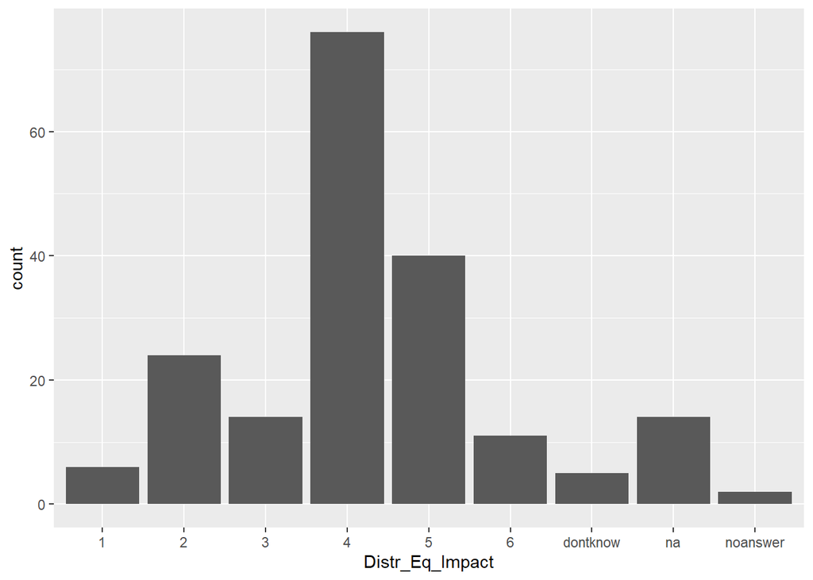

```r
ggplot(data_fiji, aes(Distr_Eq_Impact))+geom_bar()
```

Eliminate NA and don’t knows (including 6), and noanswer

```r
data_fiji_dist <- data_fiji[data_fiji$Distr_Eq_Impact!=6,]

data_fiji_dist <- data_fiji_dist[data_fiji_dist$Distr_Eq_Impact!=7,]

data_fiji_dist <- data_fiji_dist[data_fiji_dist$Distr_Eq_Impact!="dontknow",]

data_fiji_dist<- data_fiji_dist[data_fiji_dist$Distr_Eq_Impact!="noanswer",]

which(is.na(data_fiji_dist$Distr_Eq_Impact))
```

```
## integer(0)
```

```r
data_fiji_dist <- data_fiji_dist[data_fiji_dist$Distr_Eq_Impact!="na",]
```

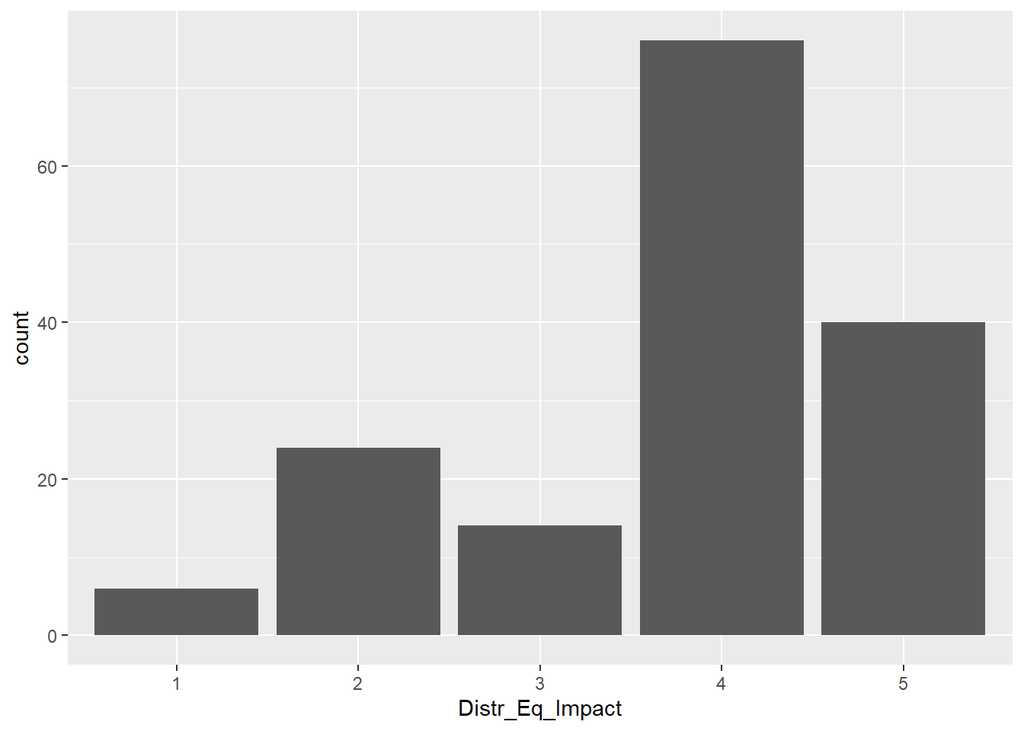

```r
ggplot(data_fiji_dist, aes(Distr_Eq_Impact))+geom_bar()
```

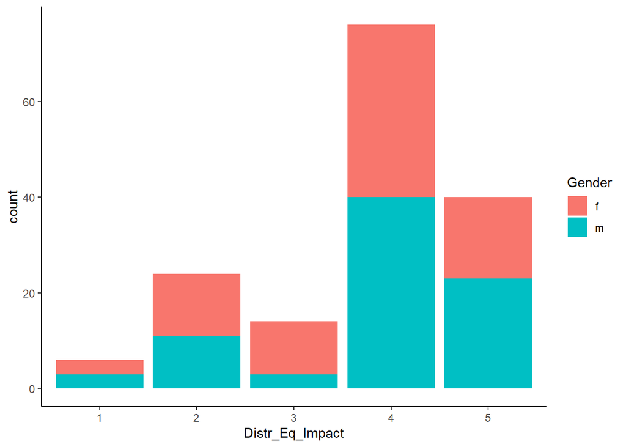

```r
ggplot(data_fiji_dist, aes(Distr_Eq_Impact,fill=Gender))+geom_bar()+theme_classic()
```

```r
dim(data_fiji_dist)
```

```
## [1] 160 142
```

```r
which(is.na(data_fiji_dist$Age_num_sd))
```

```
## [1] 43
```

There in 1 NA in age withing data_fiji_dist.

```r
data_fiji_dist<-data_fiji_dist[-c(43),]
```

```r
str(data_fiji_dist$Distr_Eq_Impact)
```

```
##  chr [1:159] "4" "5" "5" "5" "4" "4" "4" "5" "4" "4" "3" "3" "5" "4" "4" ...
```

```r
data_fiji_dist$Distr_Eq_Impact_int<-as.integer(data_fiji_dist$Distr_Eq_Impact)
```

```r
str(data_fiji_dist$Distr_Eq_Impact_int)
```

```
##  int [1:159] 4 5 5 5 4 4 4 5 4 4 ...
```

Likert plot

```r
data_fiji_dist$Distr_Eq_Impact_cat<-as.factor(ifelse(data_fiji_dist$Distr_Eq_Impact==1,"Very unfair",
                               ifelse(data_fiji_dist$Distr_Eq_Impact==2, "Unfair",
                                      ifelse(data_fiji_dist$Distr_Eq_Impact==3, "Neutral",
                                             ifelse(data_fiji_dist$Distr_Eq_Impact==4, "Fair","Very fair")))))
```

```r
gender_summary<-data_fiji_dist%>%
  group_by(Gender)%>%
  count(name="n_answers")
```

```r
gender_summary
```

```
## # A tibble: 2 x 2
## # Groups:   Gender [2]
##   Gender n_answers
##   <fct>      <int>
## 1 f             79
## 2 m             80
```

```r
edu_summary<-data_fiji_dist%>%
  group_by(Education_cat3)%>%
  count(name="n_answers")
```

```r
mar_summary<-data_fiji_dist%>%
  group_by(Marital_status)%>%
  count(name="n_answers")
```

```r
genmig_summary<-data_fiji_dist%>%
  group_by(Gender,migrant2)%>%
  count(name="n_answers")
```

```r
genmar_summary<-data_fiji_dist%>%
  group_by(Gender,Marital_status)%>%
  count(name="n_answers")
```

```r
genedu_summary<-data_fiji_dist%>%
  group_by(Gender,Education_cat3)%>%
  count(name="n_answers")
```

```r
de_summary<-data_fiji_dist%>%
  group_by(Gender, Distr_Eq_Impact_cat)%>%
  count(name="n_answers")%>%
  group_by(Gender)
#%>%
  #mutate(percent_answers=n_answers/sum(n_answers))%>%
  #ungroup()%>%
#mutate(percent_answers_label = percent(percent_answers,accuracy=1))
```

wide format

```r
de_summary
```

```
## # A tibble: 10 x 3
## # Groups:   Gender [2]
##    Gender Distr_Eq_Impact_cat n_answers
##    <fct>  <fct>                   <int>
##  1 f      Fair                       36
##  2 f      Neutral                    11
##  3 f      Unfair                     13
##  4 f      Very fair                  16
##  5 f      Very unfair                 3
##  6 m      Fair                       40
##  7 m      Neutral                     3
##  8 m      Unfair                     11
##  9 m      Very fair                  23
## 10 m      Very unfair                 3
```

````
```r
de_gender_wide<-de_summary%>%
pivot_wider(names_from = Distr_Eq_Impact_cat, values_from =n_answers)
```



```r
de_gender_wide
```

```
## # A tibble: 2 x 6
## # Groups:   Gender [2]
##   Gender  Fair Neutral Unfair `Very fair` `Very unfair`
##   <fct>  <int>   <int>  <int>       <int>         <int>
## 1 f         36      11     13          16             3
## 2 m         40       3     11          23             3
```


```r
col_order<-c("Gender","Very unfair", "Unfair", "Neutral", "Fair", "Very fair")
```


```r
de_gender_wide_or<-de_gender_wide[,col_order]
```



```r
de_gender_wide_or
```

```
## # A tibble: 2 x 6
## # Groups:   Gender [2]
##   Gender `Very unfair` Unfair Neutral  Fair `Very fair`
##   <fct>          <int>  <int>   <int> <int>       <int>
## 1 f                  3     13      11    36          16
## 2 m                  3     11       3    40          23
```
````

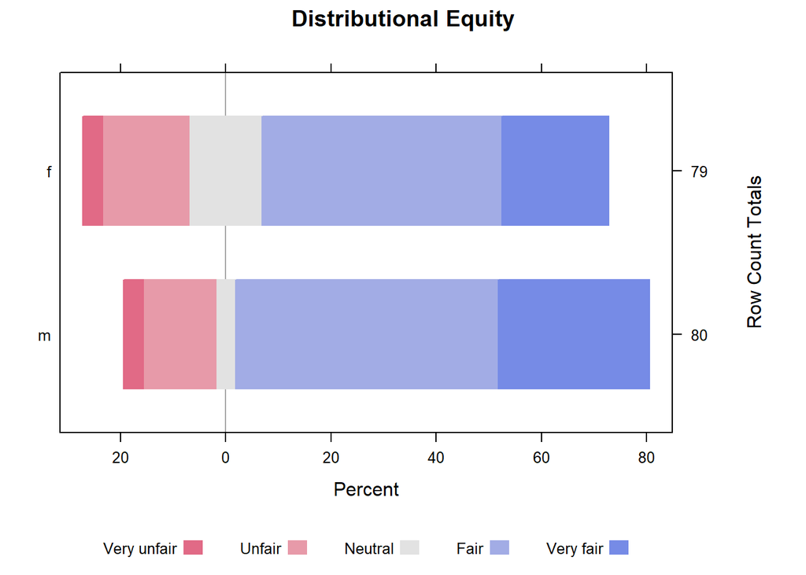

```r
HH::likert(Gender~.,data=de_gender_wide_or, ylab=NULL, ReferenceZero=3,as.percent=TRUE,
           main = list("Distributional Equity"))
```

```r
plot_de<-HH::likert(Gender~.,data=de_gender_wide_or, ylab=NULL, ReferenceZero=3,as.percent=TRUE,
           main = list("Distributional Equity"))
```

```r
Gender<-c("Women", "Men")
Very_unfair<-c(3,3)
Unfair<-c(13,11)
Neutral<-c(10,3)
Fair<-c(35,40)
Very_fair<-c(16,23)

df_dist_eq<-data.frame(Gender, Very_unfair, Unfair, Neutral, Fair, Very_fair)
print(df_dist_eq)
```

```
##   Gender Very_unfair Unfair Neutral Fair Very_fair
## 1  Women           3     13      10   35        16
## 2    Men           3     11       3   40        23
```

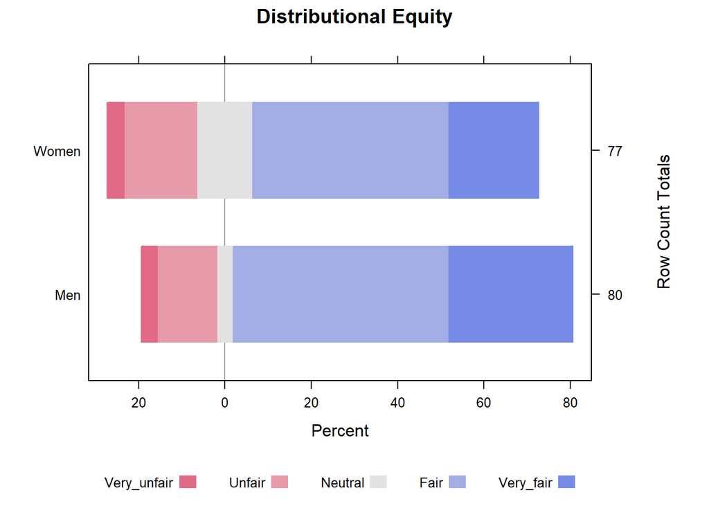

```r
HH::likert(Gender~.,data=df_dist_eq, ylab=NULL, ReferenceZero=3, as.percent=TRUE,
           main = list("Distributional Equity"))
```

PROCEDURAL EQUITY

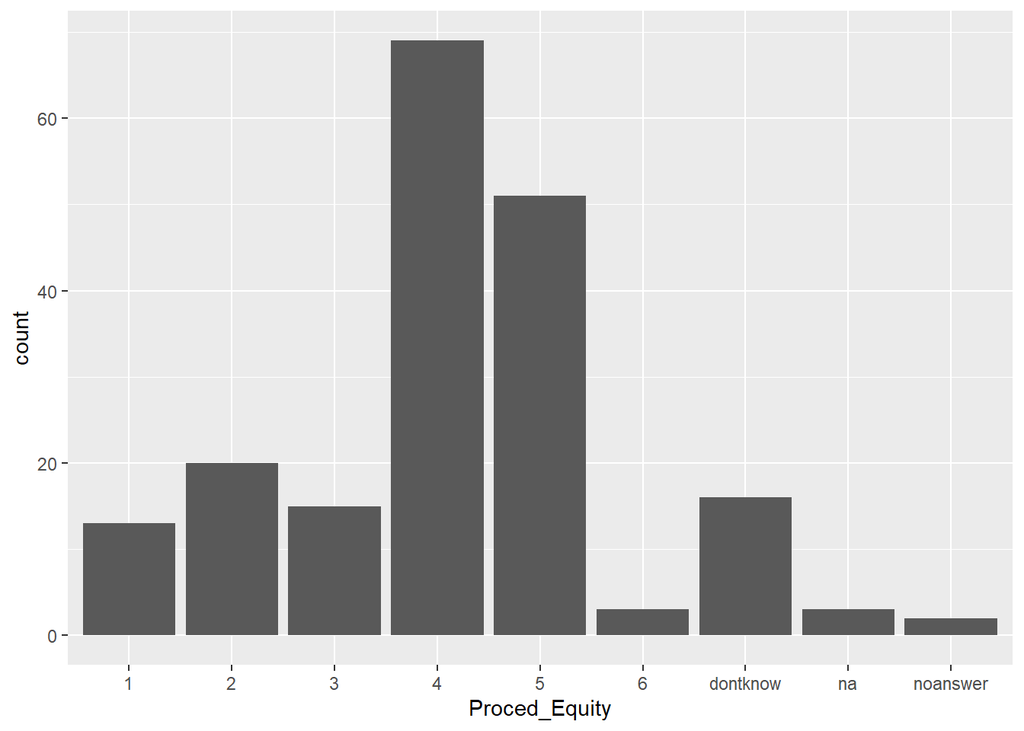

```r
ggplot(data_fiji, aes(Proced_Equity))+geom_bar()
```

Eliminate NA and don’t knows (including 6), and noanswer

```r
data_fiji_proced <- data_fiji[data_fiji$Proced_Equity!=6,]

data_fiji_proced <- data_fiji_proced[data_fiji_proced$Proced_Equity!="dontknow",]

data_fiji_proced<- data_fiji_proced[data_fiji_proced$Proced_Equity!="noanswer",]

which(is.na(data_fiji_proced$Proced_Equity))
```

```
## integer(0)
```

```r
data_fiji_proced<- data_fiji_proced[data_fiji_proced$Proced_Equity!="na",]
```

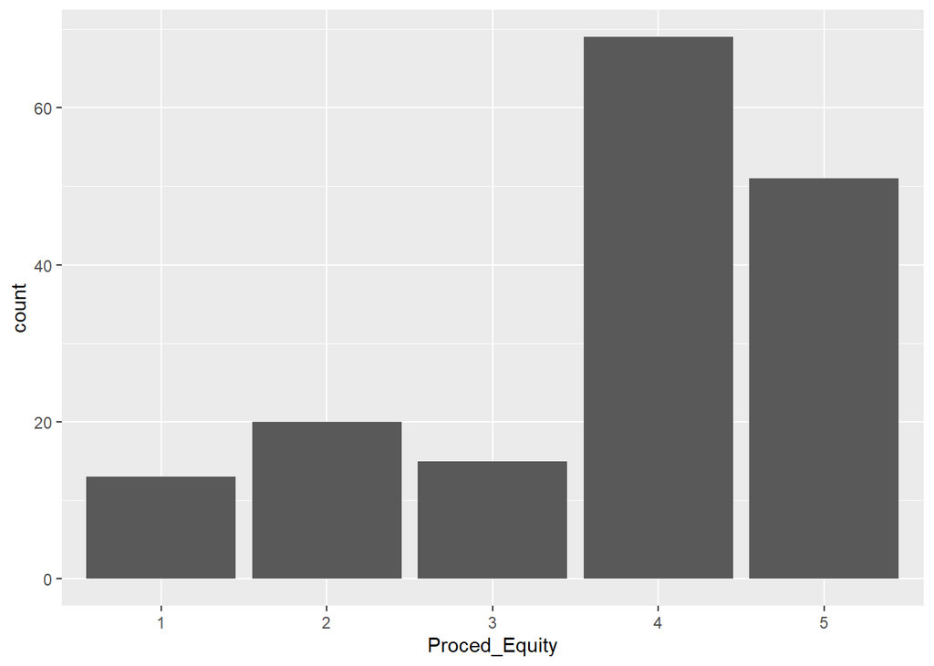

```r
ggplot(data_fiji_proced, aes(Proced_Equity))+geom_bar()
```

```r
dim(data_fiji_proced)
```

```
## [1] 168 142
```

```r
str(data_fiji_proced$Proced_Equity)
```

```
##  chr [1:168] "4" "5" "5" "5" "5" "4" "4" "4" "4" "3" "5" "4" "4" "4" "4" ...
```

```r
data_fiji_proced$Proced_Equity_int<-as.integer(data_fiji_proced$Proced_Equity)
```

```r
str(data_fiji_proced$Proced_Equity_int)
```

```
##  int [1:168] 4 5 5 5 5 4 4 4 4 3 ...
```

Likert plot

```r
data_fiji_proced$Proced_Equity_cat<-as.factor(ifelse(data_fiji_proced$Proced_Equity_int==1,"Very unfair",
                               ifelse(data_fiji_proced$Proced_Equity_int==2, "Unfair",
                                      ifelse(data_fiji_proced$Proced_Equity_int==3, "Neutral",
                                             ifelse(data_fiji_proced$Proced_Equity_int==4, "Fair","Very fair")))))
```

```r
pe_summary<-data_fiji_proced%>%
  group_by(Gender, Proced_Equity_cat)%>%
  count(name="n_answers")%>%
  group_by(Gender)
#%>%
  #mutate(percent_answers=n_answers/sum(n_answers))%>%
  #ungroup()%>%
#mutate(percent_answers_label = percent(percent_answers,accuracy=1))
```

```r
pe_summary
```

```
## # A tibble: 10 x 3
## # Groups:   Gender [2]
##    Gender Proced_Equity_cat n_answers
##    <fct>  <fct>                 <int>
##  1 f      Fair                     42
##  2 f      Neutral                  10
##  3 f      Unfair                   12
##  4 f      Very fair                19
##  5 f      Very unfair               6
##  6 m      Fair                     27
##  7 m      Neutral                   5
##  8 m      Unfair                    8
##  9 m      Very fair                32
## 10 m      Very unfair               7
```

```r
gen_summary<-data_fiji_proced%>%
   group_by(Gender)%>%
   count(name="n_answers")
```

```r
mig_summary<-data_fiji_proced%>%
   group_by(migrant2)%>%
   count(name="n_answers")
```

```r
mar_summary<-data_fiji_proced%>%
   group_by(Marital_status)%>%
   count(name="n_answers")
```

```r
edu_summary<-data_fiji_proced%>%
   group_by(Education_cat3)%>%
   count(name="n_answers")
```

```r
genmig_summary<-data_fiji_proced%>%
   group_by(Gender,migrant2)%>%
   count(name="n_answers")
```

```r
genmar_summary<-data_fiji_proced%>%
   group_by(Gender,Marital_status)%>%
   count(name="n_answers")
```

```r
gened_summary<-data_fiji_proced%>%
   group_by(Gender,Education_cat3)%>%
   count(name="n_answers")
```

````
```r
pe_gender_wide<-pe_summary%>%
pivot_wider(names_from = Proced_Equity_cat, values_from =n_answers)
```



```r
pe_gender_wide
```

```
## # A tibble: 2 x 6
## # Groups:   Gender [2]
##   Gender  Fair Neutral Unfair `Very fair` `Very unfair`
##   <fct>  <int>   <int>  <int>       <int>         <int>
## 1 f         42      10     12          19             6
## 2 m         27       5      8          32             7
```



```r
pe_gender_wide_or<-pe_gender_wide[,col_order]
```
````

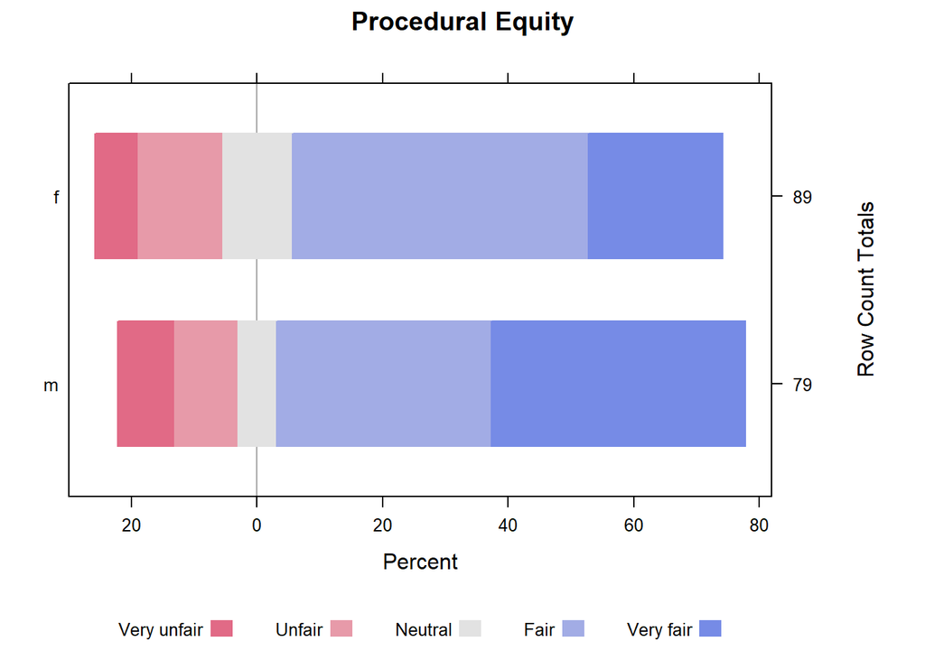

```r
HH::likert(Gender~.,data=pe_gender_wide_or, ylab=NULL, ReferenceZero=3, as.percent=TRUE,main = list("Procedural Equity"))
```

```r
plot_pe<-HH::likert(Gender~.,data=pe_gender_wide_or, ylab=NULL, ReferenceZero=3, as.percent=TRUE,main = list("Procedural Equity"))
```

```r
 library(ggpubr)
```

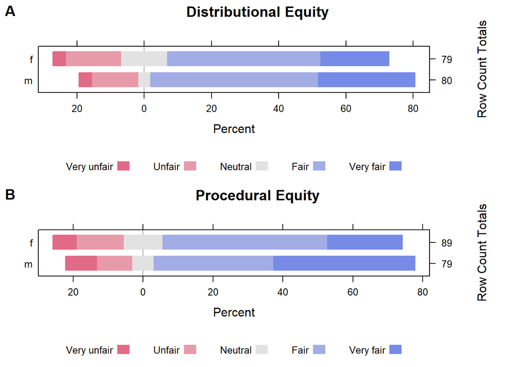

```r
    ggarrange(plot_de,plot_pe, ncol = 1, nrow = 2,
          labels = c("A", "B"))
```